# Part II - Prosper Data Presentation

## by Olamide Emida

## Investigation Overview

In this investigation, I wanted to look at the variables of loan that could influence the borrower rate. The main focus was on the following variables: loan amount, monthly income and credit grade. I introduced each variable. I showed the purpose of the loan and I plotted the relationship between borrower rate vs. loan amount, monthly income and rating grade.

## Data Overview

This data set contains 113,937 loans with 81 variables on each loan, including loan amount, borrower rate (or interest rate), current loan status, borrower income, and many others. I selected 15 variables of interest to performed my analysis. View the data [here](https://www.google.com/url?q=https://s3.amazonaws.com/udacity-hosted-downloads/ud651/prosperLoanData.csv&sa=D&ust=1581581520570000)

## Distribution of Borrower rate

Borrower rate takes a range of values between 5% and 35%. The loan borrower rate with the highest frequency is around 14%. It seems Prosper demands for higher borrower rates overall.

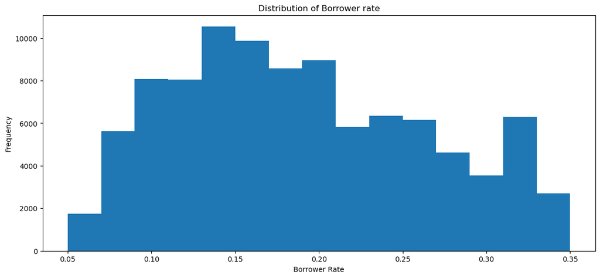

## Distribution of Loan amount

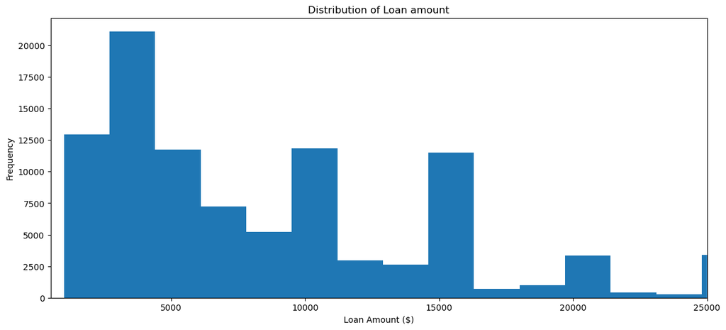

## Purpose of the Loans

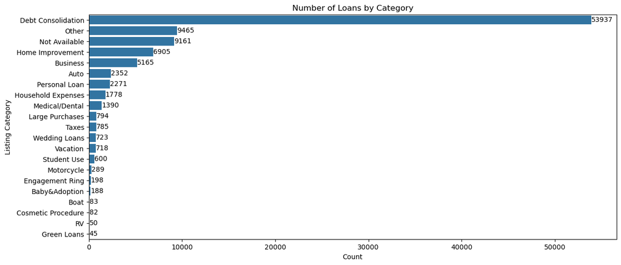

## Loan Amount vs. Borrower Rate

Suprisingly, there is a negative relationship between loan amount and borrower rate. Some borrowers of lower loan amounts below 10000 paid higher borrower rates while borrowers of loan amounts above 25000 paid below 20% as borrower rate.

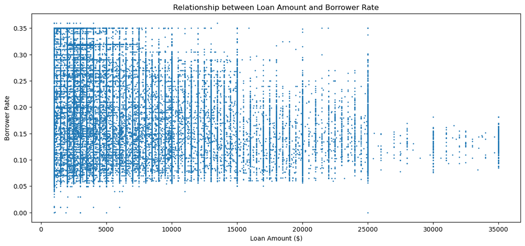

## Monthly Income and Borrower Rate by Loan Amount

There is a negative relationship between monthly income and borrower Rate. Some borrowers of lower loan amounts (below 15000) with monthly income below 10,000 paid higher borrower rates. Other borrowers earning above 10000 monthly and borrowing above 15000 paid below 25% as borrower rate.

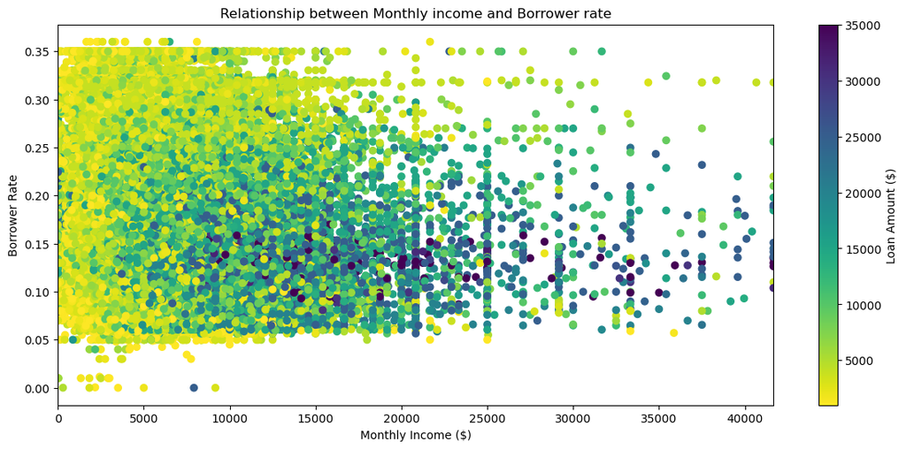

## Rating Grade vs Borrower Rate

The loans are graded from AA to HR. AA represents loans with the lowest risk and HR represents loan with the highest risks. There is a positive correlation between rating grade and borrower rate. As the grade (riskiness) increases, borrower rate increases on average.

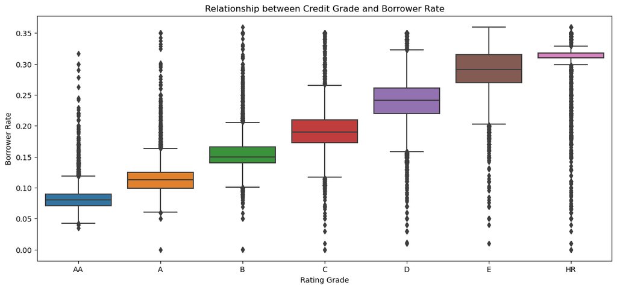

## Monthly Income and Borrower Rate by Rating Grade

The negative correlation between monthly incomes and borrower rates only applies to loans with lower risks (AA, A, and B). As income increases, borrower rate decreases for these levels of risk.

Therefore, rating grade seems to be the major indicator of borrower rate. Irrespective of the borrowers' monthly incomes and loan amounts, loans with high credit grade (high risk) tend to have high borrower rates.

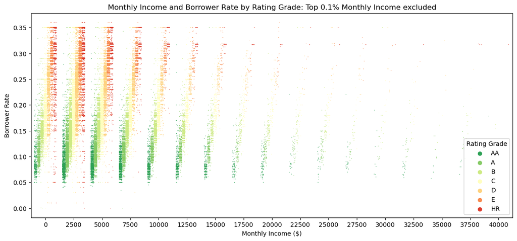